# 第九組：結合jiebar與Tidy text套件，處理中文文字資料（三國演義）

第九組

2019/03/19

Abstract

結合jiebar與Tidy text套件，處理中文文字資料（三國演義）

# 系統參數設定

```r
Sys.setlocale(category = "LC_ALL", locale = "zh_TW.UTF-8") # 避免中文亂碼
```

```
## [1] ""
```

## 安裝需要的packages

```r
packages = c("dplyr", "tidytext", "jiebaR", "gutenbergr", "stringr", "wordcloud2", "ggplot2", "tidyr", "scales")
existing = as.character(installed.packages()[,1])
for(pkg in packages[!(packages %in% existing)]) install.packages(pkg)
```

```r
require(dplyr)
require(tidytext)
require(jiebaR)
require(gutenbergr)
```

```r
library(stringr)
library(wordcloud2)
library(ggplot2)
library(tidyr)
library(scales)
require(caTools)
require(knitr)
```

# 書籍下載

- 從 gutenberg 下載 id 為 23950 的【三國演義】書籍
- 整理書籍成一列一句的資料格式

```r
# 下載 "三國演義" 書籍，並且將text欄位為空的行給清除，以及將重複的語句清除

red_org <- gutenberg_download(23950) %>% filter(text!="") %>% distinct(gutenberg_id, text)
```

```
## Determining mirror for Project Gutenberg from http://www.gutenberg.org/robot/harvest
```

```
## Using mirror http://aleph.gutenberg.org
```

```r
doc = paste0(red_org$text,collapse = "") #將text欄位的全部文字合併
docVector = unlist(strsplit(doc,"[。．]"), use.names=FALSE) #以全形或半形句號斷句
red = data.frame(gutenberg_id = "23950" , text = docVector,stringsAsFactors = FALSE) #gutenberg_id換成自己的書本id
```

## 三國演義大綱

```r
history_tmp=read.csv("三國演義歷史.csv",header=FALSE,stringsAsFactors=FALSE,fileEncoding="big5")
my_str_split<-function(x,i) lapply(strsplit(x,split="~"),function(y) y[i]) %>% unlist %>% as.numeric()
#history_tmp$V1[9]="長坂坡"
history_tmp2=history_tmp %>% mutate(start=my_str_split(V2,1),end=my_str_split(V2,2)) %>% select(-V2);
colnames(history_tmp2)[1]="大綱"
history_tmp2 %>% kable
```

| 大綱 | start | end |
| --- | --- | --- |
| 破黃巾，殺閹宦 | 1 | 2 |
| 收呂布，除董卓 | 3 | 9 |
| 曹操發跡 | 10 | 14 |
| 斬呂布 | 15 | 19 |
| 密謀誅曹 | 20 | 24 |
| 關羽附曹，孫權承兄 | 25 | 29 |
| 掃清袁氏，統一北方 | 30 | 33 |
| 三顧茅廬，孔明出山 | 34 | 40 |
| 長?坡 | 41 | 42 |
| 赤壁之戰 | 43 | 50 |
| 三氣周瑜 | 51 | 57 |
| 戰馬超 | 58 | 59 |
| 劉備入川 | 60 | 65 |
| 戰合肥，立魏嗣 | 66 | 69 |
| 取漢中 | 70 | 73 |
| 荊州失，關公死 | 74 | 77 |
| 魏篡漢，蜀稱帝 | 78 | 80 |
| 夷陵大敗，劉備託孤 | 81 | 86 |
| 七擒孟獲 | 87 | 90 |
| 六出祁山，孔明病逝 | 91 | 105 |
| 九伐中原 | 106 | 115 |
| 破西蜀 | 116 | 118 |
| 司馬篡魏，三分歸晉 | 119 | 120 |

## 章節與關鍵字尋找

- 三國演義中每章的開始會有“第XXX回：”為標題
- 關鍵字字句尋找
- 劉備 ：【劉備】、【玄德】
- 關羽 ：【雲長】、【關羽】、【關公】
- 張飛 ：【張飛】、【翼德】、【張翼德】
- 諸葛亮：【諸葛亮】、【孔明】
- 曹操 ：【曹操】、【阿瞞】、【孟德】
- 魏國 ：【魏兵】
- 蜀國 ：【蜀兵】
- 吳國 ：【吳兵】

```r
# 根據上方整理出來的規則，我們可以使用正規表示式，將句子區分章節
red <- red %>%
  mutate(chapter = cumsum(str_detect(text, regex("第.*回："))),
         chapter_ind = (str_detect(text, regex("第.*回："))),
         liu_bei=(str_detect(text, regex("劉備|玄德"))),
         cao_cao=(str_detect(text, regex("曹操|阿瞞|孟德"))),
         guan_yu=(str_detect(text, regex("雲長|關公|關羽"))),
         yi_de=(str_detect(text, regex("張翼德|翼德|張飛"))),
         kong_ming=(str_detect(text, regex("孔明|諸葛亮"))),
         wei_guo=str_detect(text, regex("魏兵")),
         shu_guo=str_detect(text, regex("蜀兵")),
         wu_guo=str_detect(text, regex("吳兵"))
         ) %>%
    mutate(chapter_content=ifelse(chapter_ind,gsub(".*第.*回：(.*)(　　).*", "\\1", text),""))
red_chapter=red %>% filter(chapter_ind) %>% select(chapter,chapter_content);
#   mutate(chapter_content=ifelse(chapter_ind,gsub("(　　).*","", text),""))
# red_chapter=red %>% filter(chapter_ind) %>% select(chapter,chapter_content);
```

- 計算三國演義每一回，各國兵句子出現頻率
- 由該圖能簡單看出三國的創立和交戰火熱情況
- 將最高點的章節名稱放入

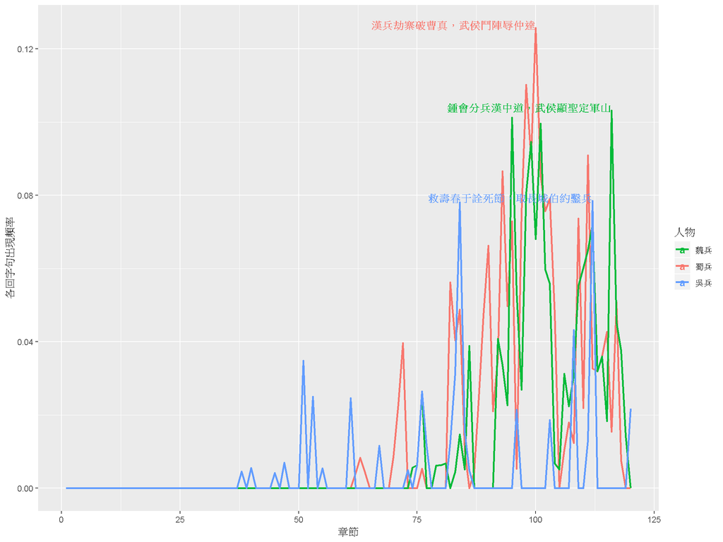

```r
# 根據上方整理出來的規則，我們可以使用正規表示式，將句子區分章節
red_group <- red %>% select(-gutenberg_id,-text,-chapter_content,-chapter_ind) %>% select(chapter,wei_guo,shu_guo,wu_guo) %>%
  group_by(chapter) %>% summarise_all(mean)

red_group2 <- red_group %>% gather(word,prop,-chapter) %>% group_by(word)%>% left_join(red_chapter,by="chapter") %>%
  mutate(chapter_show=ifelse(prop==max(prop),chapter_content,""))

red_group2 %>% ggplot(aes(x = chapter, y=(prop), fill="type", color=factor(word))) +
  geom_line(size=1) +
  scale_colour_discrete(name = "人物",breaks=c("wei_guo", "shu_guo", "wu_guo"),labels =c("魏兵","蜀兵","吳兵"))+ylab("各回字句出現頻率")+xlab("章節")+
  geom_text(aes(label = chapter_show), vjust = 0.02,hjust=1,fontface="bold")
```

- 同樣計算三國演義每一回，人物在句子出現頻率
- 由該圖能看出作者描述各人物的情況
- 劉備各回的描述較多,並且部分最高的其中一回 0.4 的句子都有劉備參與 (人物飽滿 )
- 描述關羽的回數相比於劉備較少，但在最高回有 0.45 的句子都有關羽參與 (人物飽滿 )
- 孔明的描述主要在七擒孟獲和與司馬懿交戰才大量提升
- 張飛描述相對其他人較少
- 將最高點的章節名稱放入

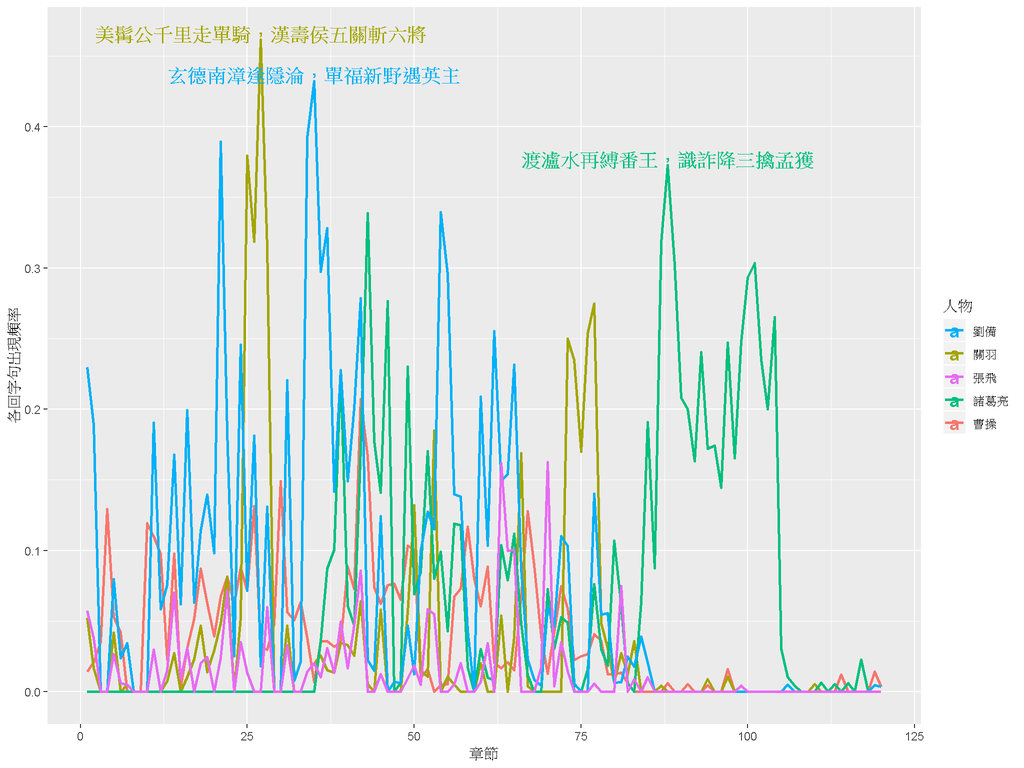

```r
# 根據上方整理出來的規則，我們可以使用正規表示式，將句子區分章節
red_group <- red %>% select(-gutenberg_id,-text,-chapter_content,-chapter_ind) %>% select(-wei_guo,-shu_guo,-wu_guo) %>%
  group_by(chapter) %>% summarise_all(mean)

red_group2 <- red_group %>% gather(word,prop,-chapter) %>% group_by(word)%>% left_join(red_chapter,by="chapter") %>%
  mutate(chapter_show=ifelse(prop>=max(prop),chapter_content,""))

red_group2$chapter_show[red_group2$word=="yi_de"]=""
red_group2$chapter_show[red_group2$word=="cao_cao"]=""

red_group2 %>% ggplot(aes(x = chapter, y=(prop), fill="type", color=factor(word))) +
  geom_line(size=1) +
  scale_colour_discrete(name = "人物",breaks=c("liu_bei", "guan_yu", "yi_de","kong_ming","cao_cao"),labels =c("劉備","關羽","張飛","諸葛亮","曹操"))+ylab("各回字句出現頻率")+xlab("章節")+
  geom_text(aes(label = chapter_show), vjust = 0.02,hjust=0.5,fontface="bold",size=5)
```

## 中文斷詞

- 將三國演義詞典【san_guo.scel_2019-03-16_17_23_08_trad.dict】納入建立 R jieba worker
- 進行斷詞

```r
# 使用三國演義專有名詞字典
jieba_tokenizer <- worker(user = 'san_guo.scel_2019-03-16_17_23_08_trad.dict', stop_word = "stop_words.txt")
# 設定斷詞function
red_tokenizer <- function(t) {
  lapply(t, function(x) {
    tokens <- segment(x, jieba_tokenizer)
    return(tokens)
  })
}

tokens <- red %>% unnest_tokens(word, text, token=red_tokenizer)
```

## 計算詞頻

- 只保留字數大於 1 與詞頻大於 10 的字
- 列出詞頻前 20 大的字

```r
# 計算詞彙的出現次數，如果詞彙只有一個字則不列入計算
tokens_count <- tokens %>%
  filter(nchar(.$word)>1) %>%
  group_by(word) %>%
  summarise(sum = n()) %>%
  filter(sum>10) %>%
  arrange(desc(sum))

# 印出最常見的20個詞彙
head(tokens_count, 20) %>% kable
```

| word | sum |
| --- | --- |
| 玄德 | 1779 |
| 孔明 | 1644 |
| 曹操 | 922 |
| 將軍 | 725 |
| 丞相 | 533 |
| 關公 | 501 |
| 雲長 | 430 |
| 荊州 | 408 |
| 張飛 | 364 |
| 引兵 | 359 |
| 呂布 | 355 |
| 商議 | 341 |
| 軍士 | 321 |
| 魏延 | 321 |
| 主公 | 319 |
| 大喜 | 310 |
| 孫權 | 309 |
| 趙雲 | 309 |
| 左右 | 292 |
| 軍馬 | 289 |

# 文字雲

畫出詞頻的文字雲

```r
tokens_count2=tokens_count %>% mutate(sum=(sum)^1 %>% as.integer())
tokens_count2%>% wordcloud2()
```

[interactive chart not shown]

# 各章節長度，以語句數來計算

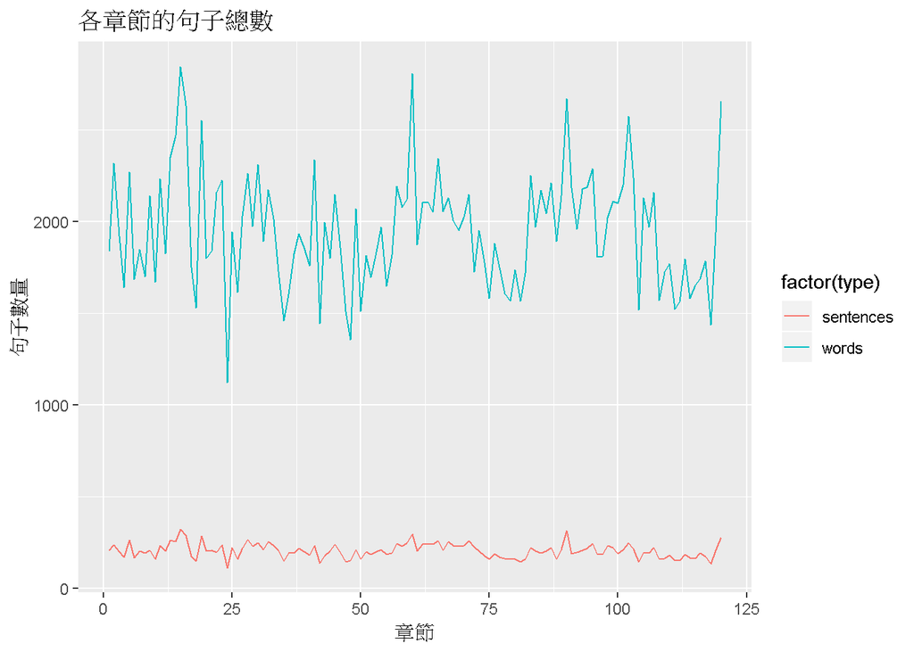

```r
plot <-
  bind_rows(
    red %>%
      group_by(chapter) %>%
      summarise(count = n(), type="sentences"),
    tokens %>%
      group_by(chapter) %>%
      summarise(count = n(), type="words")) %>%
  group_by(type)%>%
  ggplot(aes(x = chapter, y=count, fill="type", color=factor(type))) +
  geom_line() +
  ggtitle("各章節的句子總數") +
  xlab("章節") +
  ylab("句子數量") #+
  #theme(text = element_text(family = "Heiti TC Light"))
plot
```

# 書籍撰寫前 80 回於後 40 回字頻差異

- 由人物頻率圖可觀測出 80 為一個分界點
- 計算前八十回 和 後四十回 的詞彙在全文中出現比率

```r
frequency <- tokens %>% mutate(part = ifelse(chapter<=80, "First 80", "Last 40")) %>%
  filter(nchar(.$word)>1) %>%
  mutate(word = str_extract(word, "[^0-9a-z']+")) %>%
  mutate(word = str_extract(word, "^[^一二三四五六七八九十]+")) %>%
  count(part, word)%>%
  group_by(part) %>%
  mutate(proportion = n / sum(n)) %>%
  select(-n) %>%
  spread(part, proportion) %>%
  gather(part, proportion, `Last 40`)
frequency[is.na(frequency)]=min(frequency %>% select(`First 80`,proportion))
```

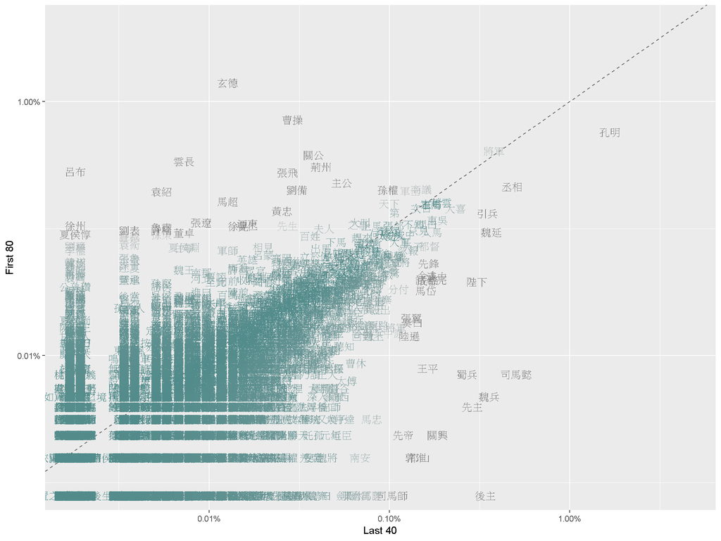

```r
ggplot(frequency, aes(x = proportion, y = `First 80`, color = abs(`First 80` - proportion))) +
  geom_abline(color = "gray40", lty = 2) +
  #geom_jitter(alpha = 0.01, size = 2.5, width = 0.01, height = 0.01) +
  #geom_point() +
  geom_text(aes(label = word), vjust = 1.5) +
  scale_x_log10(labels = percent_format()) +
  scale_y_log10(labels = percent_format()) +
  scale_color_gradient(limits = c(0, 0.001), low = "darkslategray4", high = "gray75") +
  theme(legend.position="none") +
  labs(y = "First 80", x = "Last 40")
```

# 額外補充

> 使用搜狗詞彙庫  
> 搜狗輸入法是中國主流的拼音輸入法，在中國的市佔率高達50%。  
> 並且，其官網提供了眾多專有詞彙的詞彙庫供使用者免費下載。  
> 詳情可以參考一下連結：  
> https://pinyin.sogou.com/dict/

```r
# 安裝packages
packages = c("readr", "devtools", "stringi", "pbapply", "Rcpp", "RcppProgress")
existing = as.character(installed.packages()[,1])
for(pkg in packages[!(packages %in% existing)]) install.packages(pkg)
```

```r
# 載入library
library(readr)
library(devtools)

# 解碼scel用
#install_github("qinwf/cidian")
library(cidian)
# 簡體轉繁體套件
#install_github("qinwf/ropencc")
library(ropencc)
```

```r
# 解碼scel檔案
decode_scel(scel = "./san_guo.scel",cpp = TRUE)
```

```
## output file: ./san_guo.scel_2019-03-18_23_35_35.dict
```

```r
# 讀取解碼後生成的詞庫檔案
scan(file="./san_guo.scel_2019-03-16_17_23_08.dict",
      what=character(),nlines=50,sep='\n',
      encoding='utf-8',fileEncoding='utf-8')
```

[output not shown]

```r
dict <- read_file("./san_guo.scel_2019-03-16_17_23_08.dict")
# 將簡體詞庫轉為繁體
cc <- converter(S2TW)
dict_trad <- cc[dict]
write_file(dict_trad, "./san_guo.scel_2019-03-16_17_23_08_trad.dict")
```

```r
# 讀取轉換成繁體後的詞庫檔案
scan(file="./san_guo.scel_2019-03-16_17_23_08_trad.dict",
      what=character(),nlines=50,sep='\n',
      encoding='utf-8',fileEncoding='utf-8')
```

```
##  [1] "阿斗當皇帝軟弱無能 n" "阿斗的江山白送 n"     "阿會喃 n"
##  [4] "阿陽 n"               "哀牢 n"               "艾縣 n"
##  [7] "安北將軍 n"           "安城 n"               "安次 n"
## [10] "安德 n"               "安定 n"               "安定郡 n"
## [13] "安東將軍 n"           "安豐 n"               "安故 n"
## [16] "安廣 n"               "安國 n"               "安漢 n"
## [19] "安樂 n"               "安樂公 n"             "安陵 n"
## [22] "安陸 n"               "安彌 n"               "安南將軍 n"
## [25] "安平 n"               "安平國 n"             "安丘 n"
## [28] "安世 n"               "安市 n"               "安熹 n"
## [31] "安西將軍 n"           "安陽 n"               "安夷 n"
## [34] "安邑 n"               "安遠將軍 n"           "安眾 n"
## [37] "奧汀多賴把 n"         "鰲頭兩刃斧 n"         "媼圍 n"
## [40] "巴郡 n"               "霸陵 n"               "八路諸侯 n"
## [43] "灞水 n"               "八校尉兵 n"           "拔用 n"
## [46] "霸者之威 n"           "白帝城託孤 n"         "白鶴 n"
## [49] "白虹 n"               "白虎銀牙 n"
```